# Causality and the Geodetector?

Author

Levi John Wolf

In general, I think the Q-statistic is a very helpful diagnostic for understanding the variance partitioning across a spatial domain. But, this “axiom” from the new [Wang et al. (2024) paper published in the Annals](https://doi.org/10.1080/24694452.2023.2289982) really caught my attention:

> Our axiom is that if $X$ causes $Y$, then their spatial patterns (spatial stratified heterogeneities) would tend to be coupled, in addition to displaying a significant Pearson’s correlation.

Namely, this caught my eye because it’s not true in general: it’s only true if $X$ is a sole cause of $y$. In fact, it’s very easy to create a case where a variable causes an outcome, but is uncorrelated with it. This is not unique to the spatial case, but is easy to illustrate with spatially-patterned variables. The simplest case is a mediator variable:

```
flowchart LR
  X[X] --> M(Mediator)
  M --> Y[Y]
```

```python
import numpy
import matplotlib.pyplot as plt
import seaborn
numpy.random.seed(112112)
X = numpy.arange(100) + numpy.random.normal(scale=5, size=100)
M = numpy.arange(100)[::-1] + numpy.random.normal(scale=5, size=100)
y = X*M + numpy.random.normal(size=100)
```

We can make these spatially patterned, or we can ignore spatial patterning—either way, a mediator and a “causal” variable together can force the correlatoion between the observed and outcome variables to be arbitrarily far from the “true” causal effect relating the cause and the outcome.

In this case, $X$ causes $y$ through a mediator variable. However, the mediator “filters” the pattern of $X$, resulting in an outcome that is quite distinct from the pattern of $X$:

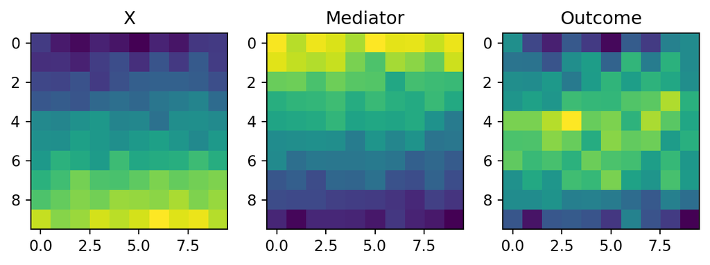

```python
Xm = X.reshape(10,10)
Mm = M.reshape(10,10)
ym = y.reshape(10,10)

f,ax = plt.subplots(1,3,figsize=(8,4))
ax[0].imshow(Xm)
ax[1].imshow(Mm)
ax[2].imshow(ym)
ax[0].set_title("X")
ax[1].set_title("Mediator")
ax[2].set_title("Outcome")
plt.show()
```

You can see this case that the mediator is the inverse pattern of $X$, the causal effect we observe. Due to the relationship caused by the causal diagram above, this is akin to a generating function like $y=-x^2 + x$ where the maximum is aligned with the horizontal axis, towards the middle of the vertical axis. Regardless, this results in zero correlation because of nonlinear structure in the relationship:

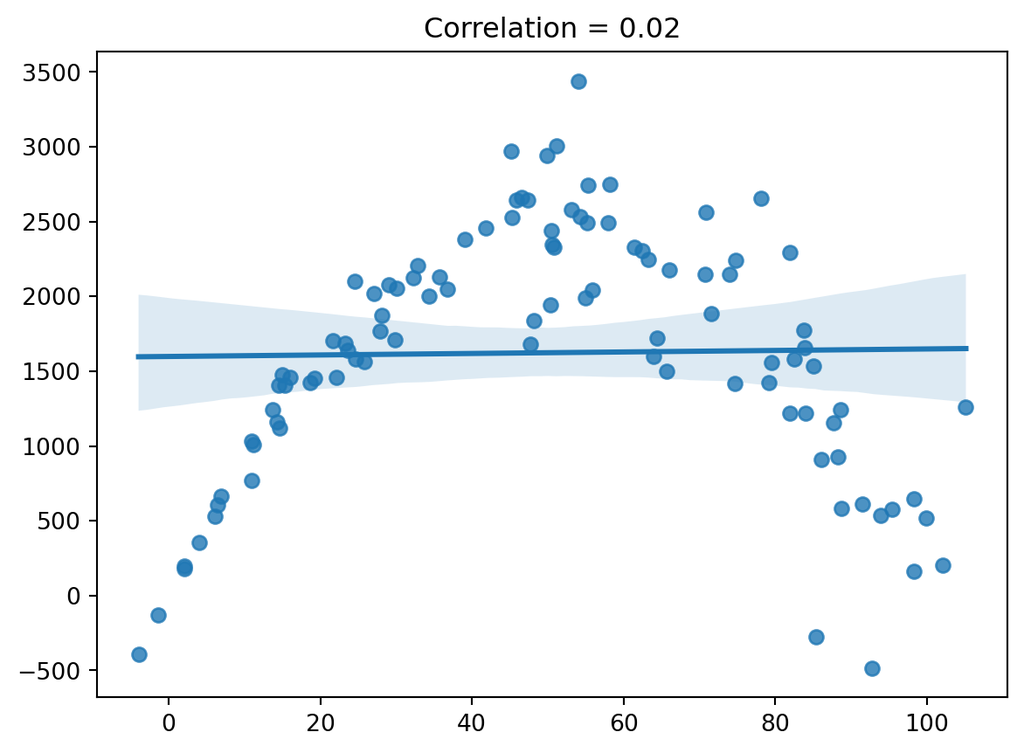

```python
seaborn.regplot(x=X, y=y)
plt.title(f"Correlation = {numpy.corrcoef(X,y)[0,1]:.2f}")
plt.show()
```

I think it’s pretty important to latch onto the concepts of causality from wider social sciences and computer science literature. Indeed, I’ve just gotten back from a [Dagstuhl seminar on spatial causal inference!](https://www.dagstuhl.de/en/seminars/seminar-calendar/seminar-details/24202)

But, this paper, despite its interesting new statistic, does not clearly ground this notion of causality in a specific process, or even a representation of a process that is amenable to classical concepts like spatially-patterned mediators, confounders, spillover, or interference. And, as a consequence, this section is pretty off-base from the rest of the paper, and leaves it pretty vulnerable to a simple counterexample like above!